# Variables For Predicting the Borrower Rate

## by (Preethi Philip)

## Investigation Overview

**For the presentation, I just focus on features that could affect the borrower rate, which are the original Loan Amount, Prosper rating and Loan Status. I started by showing the distribution of borrower rate and Loan Status.Then, I showed the relationship between Prosper rate vs Borrower Rate,Borrower rate vs Loan Status,Borrower rate vs Loan Amount as well as prosper rating vs other numerical variables such as StatedMonthlyIncome','MonthlyLoanPayment','LoanOriginalAmount','CreditScoreRangeLower'**.

## Dataset Overview

**The Original data set contains 113,937 loans with 81 variables on each loan, including loan amount, borrower rate (or interest rate), current loan status, borrower income, and many others.** **The Original Dataset contains so many variables.But I have selected few features for my analysis.** **'Term','LoanStatus','LoanOriginalAmount','BorrowerRate','ProsperRating(Alpha)','ProsperScore','DebtToIncomeRatio',EmploymentStatus', 'StatedMonthlyIncome','Occupation','LoanOriginationDate','MonthlyLoanPayment','CreditScoreRangeLower,**

## Distribution of BorrowerRate

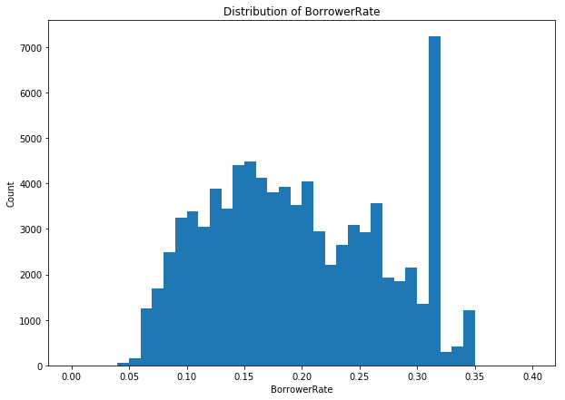

## Distribution of Loan Status

**The current status of the loan: Cancelled, Chargedoff, Completed, Current, Defaulted, FinalPaymentInProgress, PastDue. The PastDue status will be accompanied by a delinquency bucket.Most of the loans are current loan. And the other big part is the Completed loan.The number of past due and cancelled are quite low.**

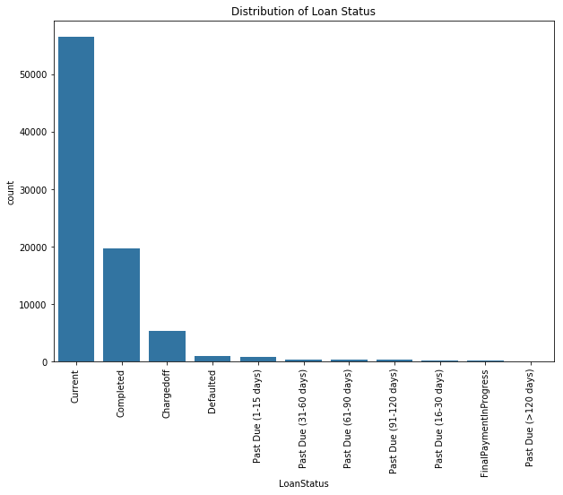

## Loan Status vs BorrowerRate

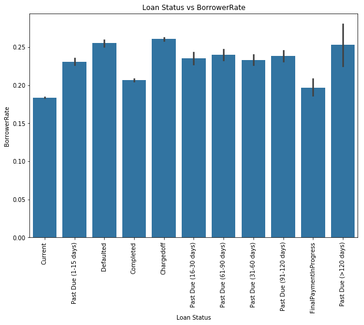

## ProsperScore vs Borrower Rate

**The Plot shows that there is a strong relation between borrower rate and Prosper score, Higher the Prosperscore, lower the Borrower rate**

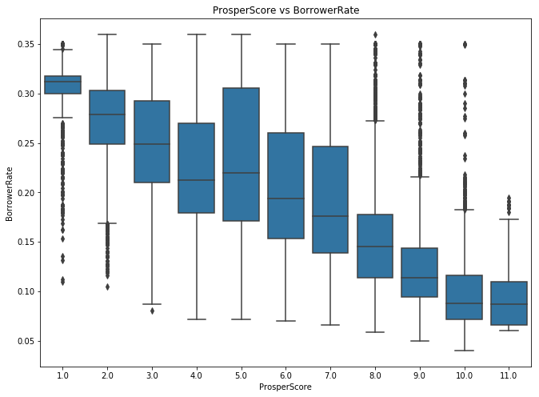

## LoanOriginalAmount vs Borrower Rate

**The borrower's rate is negatively related to the loan amount.Borrower Rate limit decreases as the loan amount increases.**

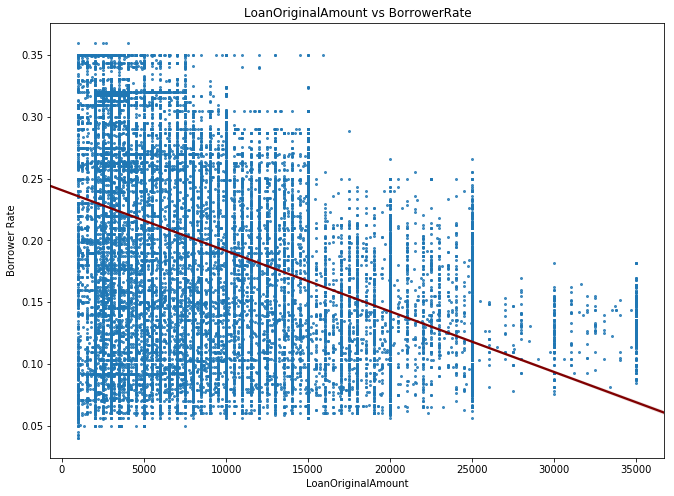

## ProsperScore vs Numerical Variables

**There is a strong relation between borrower rate Prosper score and CreditScore.Higher the Prosperscore, lower the Borrower rate.Higher the CreditScore, lower the Borrower rate. Monthly loan payment and Prosper score has a positive correlation. Monthly loan payment and loan original amount has also a strong correlation. Borrowers who have the highest credit score and prosper score will have the lowest interest rates. The higher the loan amount, the lower the borrower's rate**.

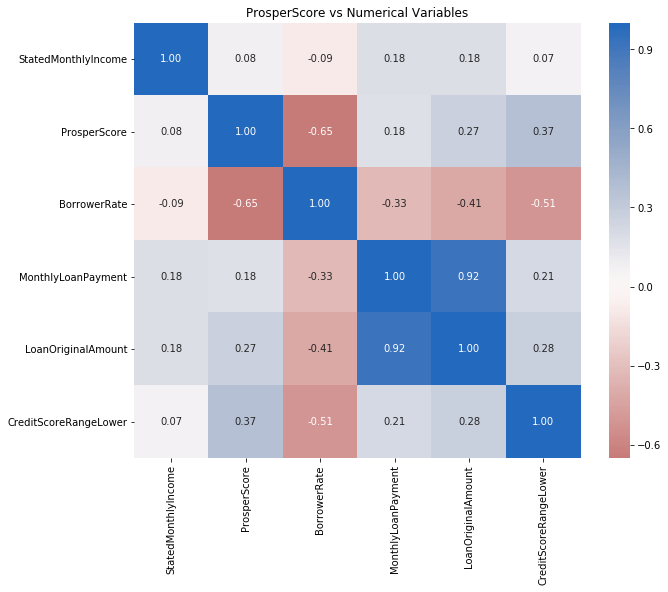